# My Bioinfo presentation

Institute of Medical Biostatistics, Epidemiology and Informatics (IMBEI), Mainz, Germany

2025-10-17

## The outline of your presentation?

1. first this
2. then that
3. aand then that again

# If you use a section for some slides…

(and you can actually navigate the slides also vertically in the ESC-view…)

Little bit of `content`

### A subheader

some content again

## Bullets

- Content authored with markdown
- Output from executable code

```r
4 + 5
```

```
[1] 9
```

## Code

[output not shown]

Here is a link to the IMBEI

## The usual content

- Some bullet
- points
- and a break after that

the things after the break

## Something in two columns

Left column

Right column

## Size of the content

Having smaller content only here

## Scrollable content

Having a scrollable slide because you might have a looooong list of bullet points

- just
- just
- just
- just
- just
- just
- just
- just
- just
- just
- like
- this

## Slide with speaker notes

Slide content

To view the notes you might need to open with `s` the Speaker View

## Asides and footnotes

Slide content

Some additional commentary of more peripheral interest.

## Asides and footnotes pt2

- Green <sup>1</sup>
- Brown
- Purple

Some additional commentary of more peripheral interest.

## Some classic plots

```r
library(ggplot2)
ggplot(airquality, aes(Temp, Ozone)) +
  geom_point() +
  geom_smooth(method = "loess")
```

## Some classic plots

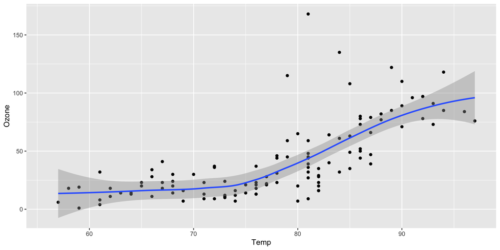

## Some classic plots - the same, but shown as fragment

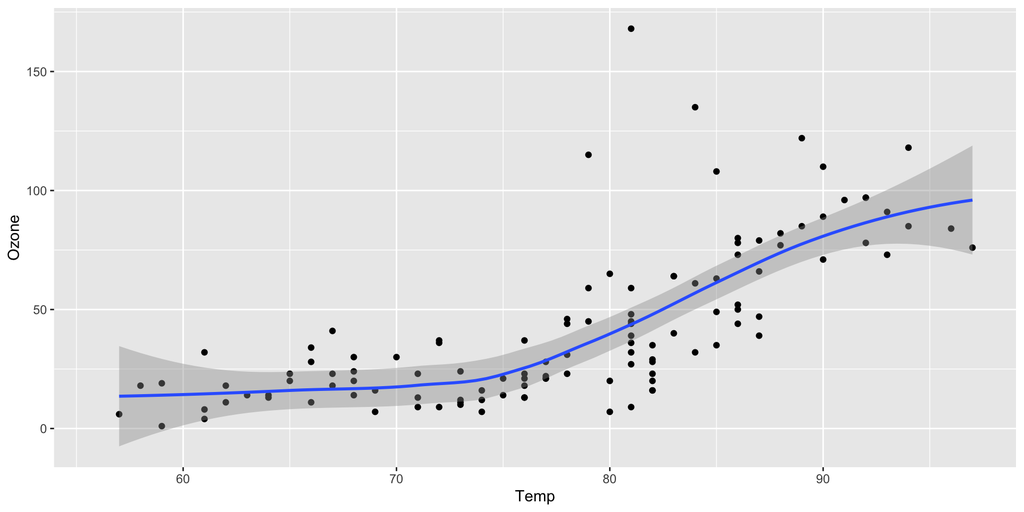

```r
library(ggplot2)
ggplot(airquality, aes(Temp, Ozone)) +
  geom_point() +
  geom_smooth(method = "loess")
```

## A slide with tabsets

- Tab A
- Tab B

Content for `Tab A`

Content for `Tab B`

## This is ultra fancy

```r
# Fill in the spot we created for a plot
output$phonePlot <- renderPlot({
  # Render a barplot
})
```

## This is ultra fancy

```r
# Fill in the spot we created for a plot
output$phonePlot <- renderPlot({
  # Render a barplot
  barplot(WorldPhones[,input$region]*1000,
          main=input$region,
          ylab="Number of Telephones",
          xlab="Year")
})
```

# The final words (?)

## Thanks & Acknowledgments

… maybe a photo of people involved?

## References?

Could be cool to have it automatically built